# Week 6: Search Engine Optimisation

Lecture

Mohammed Ali Sharafuddin

## Week 6 Lecture: Search Engine Optimisation

[figure not shown]

Discussion

**1 Introduction & Recall**

⏱ 10 min

Aims; quick poll on query intent and SERP features

Acquisition

**2 SEO Foundations**

⏱ 30 min

SERP anatomy and intent, keyword clustering, titles/meta/snippets, structure, local cues, ethical notes

Practice

**3 Guided Whole-Class Discussion**

⏱ 15 min

Given one keyword cluster, sketch H1-H3, three internal links, one snippet tweak

Assessment

**4 Attendance & Exit Check**

⏱ 5 min

Attendance, one-minute exit check

## Module Arc

**Weeks 1–2**

Foundations and Planning

→

**Weeks 3–5**

Content and Media

→

**Weeks 6–8**

Acquisition Channels

→

**Weeks 9–12**

Relationships and Measurement

→

**Weeks 13–15**

Governance and AI

> **We open the Acquisition Channels block in Week 6.** The persona and canvas from Weeks 1 and 2 now drive your keyword strategy directly. Every search query you target this week should trace back to your defined audience segment and hierarchy stage.

## Today’s Agenda

**Lecture: four activities, one hour**

1. Introduction and recall: query intent, SERP features
2. SEO Foundations: information foraging, the long tail, keyword clustering, search intent, on-page SEO, local signals, ethical outreach
3. Guided whole-class discussion: sketch a page from one cluster
4. Attendance and exit check

**Tutorial preview**

You will build an SEO mini-audit for your campaign’s primary content page:

- Capture queries from Google, People Also Ask, AlsoAsked, and AnswerThePublic
- Cluster them into one primary and two support terms, and draft H1-H3 and a snippet
- Map three internal links, and check local signals where relevant
- Record findings in the structured decision record

## Learning Objectives (1 of 2)

After studying this chapter, you should be able to:

1. Apply **information foraging theory** to explain why users conduct searches and what this implies for the design of search-optimised content.
2. Explain the **long tail of search** and identify how it applies to audience segmentation decisions in low-volume markets such as the Maldives.
3. Describe how search engines determine **relevance** through on-page signals and **authority** through off-page signals.
4. Conduct a structured **keyword research session** using public tools, classify queries by search intent type, and group related terms into a **keyword cluster** built from one primary and two supporting terms.

## Learning Objectives (2 of 2)

After studying this chapter, you should be able to:

5. Apply **on-page SEO principles** to evaluate a landing page or article against the requirements of a target keyword cluster.
6. Assess **local SEO signals**, including NAP (name, address, phone) consistency and Google Business Profile presence, for a campaign serving a geographically bounded audience.
7. Describe the relationship between **service-dominant logic** and content marketing as an SEO strategy, and apply **ethical caution** to any outreach used to earn links.
8. Produce an **SEO mini-audit** that identifies keyword cluster opportunities, on-page gaps, local signal requirements, and authority signal requirements.

> **All eight objectives are assessed in your Week 6 mini-audit submission.** Identify the two you feel least confident about and focus your self-directed hours there.

## Why Your Website Has to Compete for the SERP

> Type a query into Google and what comes back is several different things stacked on top of each other: paid ads, a local pack, organic listings, sometimes a featured snippet. Search professionals call this whole stacked page the SERP, the search engine results page.

**Every position on it is a separate competition, and none of it starts until you have a website.**

## What’s On a Search Results Page

| Position | What it is | Who covers it |
| --- | --- | --- |
| **Paid ads** | Sponsored listings at the very top | Week 7, pay-per-click |
| **Local pack** | A map with pinned businesses, for geographically anchored queries | This chapter, Local SEO Signals |
| **Featured snippet / knowledge panel** | Content pulled directly from a single page | This chapter, On-Page SEO |
| **Organic listings** | Ranked by relevance and authority | This chapter, most of today |

**Reef Edge Guesthouse** can only compete for any of those positions because it has a website: a page it owns and controls outright, unlike a social media profile a platform can change overnight or a paid ad slot that disappears the moment the budget runs out.

> Keyword clustering decides which query the page competes for. On-page structure decides whether it earns the organic listing. Local signals decide whether it earns a place in the map pack.

## How Searchers Decide to Search

> A person who types a query into a search engine has already formed a hypothesis about what they need, estimated that a search is the most efficient way to find it, and committed to investing time to evaluate the results. This is a fundamentally different audience state from someone encountering a display ad.

**Information foraging theory explains this behaviour precisely.**

## Information Foraging Theory *(Pirolli and Card, 1999)*

> Information seekers optimise the **cost** of finding relevant information against the **expected value** of what they will find. A search query is a signal that this cost-benefit calculation has already been made in favour of searching.

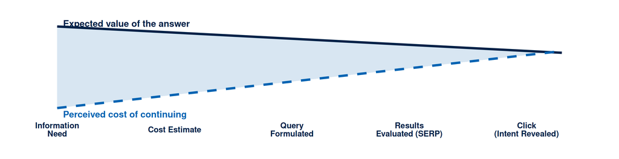

## The Long Tail of Search

> A small number of generic, high-volume queries sit at the head of the distribution. A very large number of specific, low-volume queries form the long tail. In aggregate, the tail often contains more total search traffic than the head.

**For campaigns in small markets, the long tail carries outsized weight.**

## Head, Mid-Tail, and Long-Tail Queries

| Query type | Example | Volume | Competition | Intent | Hierarchy stage |
| --- | --- | --- | --- | --- | --- |
| **Head** | “guesthouse Maldives” | Very high | Very high | Vague awareness | Awareness |
| **Mid-tail** | “affordable guesthouse Maldives snorkelling” | Moderate | Moderate | Comparative research | Knowledge to Liking |
| **Long-tail** | “best guesthouse Maldives house reef access” | Low | Low | High purchase intent | Preference to Conviction |

**The long tail principle applied to the Maldives:**

Reef Edge Guesthouse competing for “guesthouse Maldives” faces established travel platforms and price-comparison sites with thousands of inbound links. The same guesthouse competing for “best guesthouse Maldives house reef access” faces a small pool of competitors, a more specific intent, and a much more actionable conversion path.

> A keyword with 50 monthly searches that exactly matches your target segment’s intent at the Conviction stage outperforms a keyword with 5,000 monthly searches that reaches an Awareness-stage audience you have no way to convert yet.

## Long Tail and Hierarchy of Effects

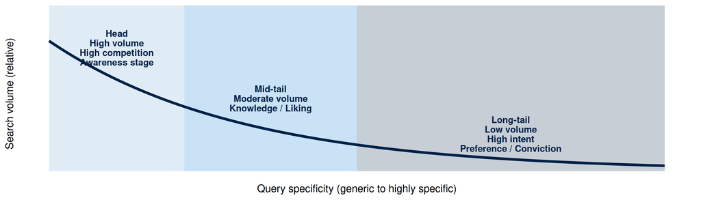

> Keyword strategy aligned to the hierarchy stage should prioritise mid-tail and long-tail terms for the current campaign objective.

## Free Tool: Ubersuggest

**No account required. Three searches per day for free.**

[ubersuggest.com](https://neilpatel.com/ubersuggest/) provides keyword volume estimates, keyword difficulty scores, and content ideas for any query.

**Tutorial task 1:** Enter your target keyword, and set the Location field to a real market your audience searches from.

**Tutorial task 2:** Record monthly search volume and keyword difficulty score.

**Tutorial task 3:** Identify long-tail variants with lower difficulty.

**Tutorial task 4:** Note which competitors rank on page one for your keyword.

> Location matters more than exact phrasing: a real Ubersuggest search for Reef Edge Guesthouse returned no usable data against “All Locations”, and returned a genuine volume figure once set to a specific source country such as India. These data points are the evidence basis for your keyword decisions in the audit.

## Keyword Clustering

> A single target keyword is rarely how a real audience searches. Building one page per exact keyword duplicates effort and splits the authority a single strong page could otherwise concentrate.

**Group queries by shared intent into one page, built around a primary term with two or three supporting terms.**

## Building a Cluster

**Two steps:**

1. **Group by shared intent, over shared wording.** “Cheap guesthouse Maldives” and “guesthouse price comparison” share commercial intent even though they share only one word.
2. **Select the strongest term as primary.** Judge strength by search volume balanced against reachable competition. Treat the remaining two or three terms as supporting terms the same page should also address in its headings and body content.

**Example cluster (Reef Edge Guesthouse):**

| Role | Term |
| --- | --- |
| Primary | “best guesthouse Maldives house reef access” |
| Support 1 | “affordable guesthouse Maldives snorkelling” |
| Support 2 | “guesthouse vs resort Maldives price” |

> Build the page around the primary term, and work the supporting terms into subheadings and body content. Three thin pages built to compete for the same three queries would only split the authority a single strong page could concentrate.

## How Search Engines Determine Rankings

> Two primary signals determine which pages rank for a given query: **relevance** (on-page) and **authority** (off-page). Technical SEO sets the floor that lets both be assessed accurately.

**Authority is built off-page, through real inbound links.**

## Authority: How Backlinks Work

**The link as a vote of confidence:** each inbound link from an external domain is interpreted as a vote that the linked page is relevant and valuable. Some votes count for more than others.

| Link characteristic | Effect on authority |
| --- | --- |
| High-authority domain (major publication, government, university) | Strong positive signal |
| Relevant topical domain (industry publication, professional body) | Positive signal |
| Low-authority or unrelated domain | Minimal signal |
| Purchased or manufactured links | Negative signal (Google penalty risk) |

**Building authority for a new domain:** it starts from near-zero authority and builds it over time through content that other sites find worth linking to.

## The SEO Signals Hub: Three Pillars

[interactive chart not shown]

> All three pillars must pass a minimum threshold before a page can compete for rankings. A technically broken page has no path to ranking. An authoritative domain with irrelevant content loses to a page that matches intent. High relevance without any domain authority loses to a competitor with both.

## Search Intent Classification

> Search intent is the underlying goal of the user at the moment of the query. Content that matches the dominant intent type for a keyword ranks; content that misses it struggles, regardless of technical quality.

**Four intent types. Four different content requirements.**

## The Four Search Intent Types

| Intent type | User goal | Example query | Appropriate content | Hierarchy stage |
| --- | --- | --- | --- | --- |
| **Informational** | Learn or understand | “what is a guesthouse in the Maldives” | Educational article, guide, tutorial | Awareness to Knowledge |
| **Navigational** | Reach a specific site or brand | “Reef Edge Guesthouse Maldives” | The exact branded page they are looking for | Any (brand recall) |
| **Commercial** | Research before deciding | “best guesthouse Maldives house reef access” | Comparison, verified guest reviews, price and amenity breakdown | Liking to Preference |
| **Transactional** | Take an action now | “book Reef Edge Guesthouse Maldives” | Landing page with clear CTA, room rates, availability | Conviction to Purchase |

> **A critical mismatch:** placing a transactional landing page (optimised for conversion) in response to an informational query earns poor rankings and high bounce rates, because the content serves a different intent than the one the user expressed.

## Search Intent Mapped to the Hierarchy of Effects

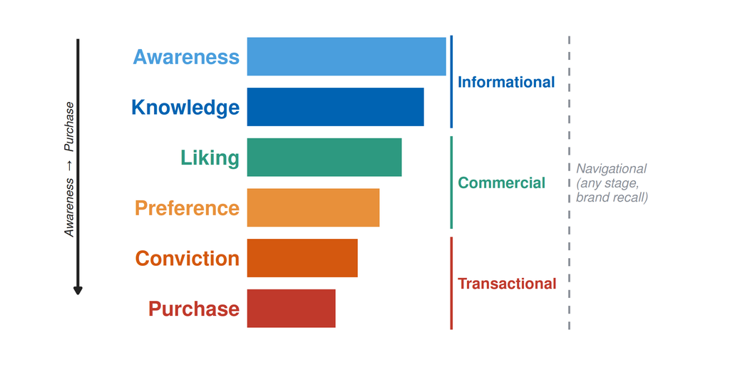

> Informational, commercial, and transactional intent each bracket a stage pair on the hierarchy of effects. Navigational intent recurs at any stage as a brand-recall signal.

## Free Tool: AnswerThePublic

**No sign-up required. Two to three searches per day for free.**

AnswerThePublic generates a visual map of the questions, prepositions, and comparisons real users type around any seed keyword. It sources data from Google’s autocomplete, which reflects actual audience language.

**How to use it:** 1. Open [answerthepublic.com](https://answerthepublic.com/) 2. Enter your campaign’s primary keyword 3. Review the “Questions” section (what, why, how, when, which) 4. Review “Prepositions” (for, near, without, with) 5. Review “Comparisons” (versus, like, and) 6. Each result is a real search query with classifiable intent

**Tutorial task:**

Enter your campaign topic. Identify:

- One question-format informational keyword
- One commercial comparison keyword
- One transactional action keyword

Classify each by intent type and hierarchy stage. These feed your Activity 2 keyword capture.

## On-Page SEO

> On-page optimisation is the practice of structuring and writing a page’s content so that its relevance to a specific query is clear to both the search engine and the user.

**The core principle: earn the ranking by being the best available answer to the query, well beyond a page that simply contains the keyword.**

## Where These Tags Actually Live

**What the searcher sees**

Tidewood Guesthouse Maldives: House-Reef Snorkelling

tidewood.example

⬇ *only after they click*

**House-Reef Snorkelling, Steps From Your Room**

Reef access and snorkelling · Price comparison

**The HTML that produces it**

```html
<head>
  <title>Tidewood Guesthouse Maldives:
         House-Reef Snorkelling</title>

  <meta name="description"
        content="Private house-reef
        snorkelling, priced below nearby
        resorts. Compare rooms and rates.">
</head>

<body>
  <h1>House-Reef Snorkelling,
      Steps From Your Room</h1>

  <h2>Reef access and snorkelling</h2>
  <h2>Price comparison</h2>
</body>
```

> **The distinction that matters:** `<title>` and `<meta description>` live in `<head>` and appear **only in the search result**. `<h1>` lives in `<body>` and appears **only on the page**. Different tags, different jobs, different readers.

## The On-Page SEO Checklist

[output not shown]

## The Same Three Tags, Audited

Real audit of **flairmi.com**, run 27 July 2026. 173 checks across 16 categories. Overall score **86/100**.

[output not shown]

> **And yet the same crawl scored this page SEO: 100/100, “Excellent”.**

## Content Quality: The Semantic Standard

Modern search engines assess **semantic relevance**, well beyond keyword repetition.

1. **Topic coverage:** does the page address the full scope of what the query’s intent implies? A page about guesthouses that omits reef access, price, or location scores poorly for commercial-intent queries where those are the evaluation criteria.
2. **Related terms:** do you use the vocabulary of the subject area naturally? A page about SEO that never mentions “keyword research”, “backlinks”, or “organic traffic” signals thin topical coverage.
3. **Freshness signals:** is the content dated? A page last updated in 2021 ranks below a page updated in 2025 for queries where recency matters (statistics, tools, platform features).
4. **User experience signals:** high bounce rate and low dwell time signal to the algorithm that the page failed to satisfy the query, reducing future ranking.
5. **Subheading structure:** H2 and H3 headings function as a semantic map for search engines, signalling the subtopics covered.

## Free Tool: Google PageSpeed Insights

**No account required. Enter any live URL. Immediate results.**

[pagespeed.web.dev](https://pagespeed.web.dev/) analyses any publicly accessible URL and returns performance scores, Core Web Vitals measurements, and specific improvement recommendations for both mobile and desktop.

[interactive chart not shown]

## Local SEO Signals

> A campaign tied to a physical location competes for a distinct ranking signal: local proximity and consistency, alongside relevance and authority.

**NAP data and Google Business Profile.**

## NAP Consistency and Google Business Profile

**NAP data:** the business name, address, and phone number as they appear across the web. Google weighs consistency when deciding which local businesses to surface for a geographically anchored query such as “guesthouse near me” or “best guesthouse Malé”.

A business name spelled two different ways across its website, its Google Business Profile, and a directory listing sends a weak consistency signal, even when every individual listing is otherwise accurate.

**Where it matters most:** campaigns with a geographically bounded audience, such as a Malé-based programme, a guesthouse, or a local service. A Maldivian guesthouse gains far more from local pack visibility than a fully remote course would.

**Google Business Profile** is the primary local signal: a free listing that surfaces in the map pack and local results, carrying hours, address, phone number, photos, and reviews.

> Consistency substitutes for the inbound-link volume a small local business rarely has the reach to build. A local business can often outrank a nationally established competitor on a local query through consistency alone.

**Check:** website, Google Business Profile, and any directory listing, for an exact match.

## Service-Dominant Logic and Content Marketing as SEO

> Content marketing functions as SEO: it is the mechanism by which authority accumulates over time.

**Vargo and Lusch (2004):** value arises through co-creation in the interaction between provider and customer, rather than sitting embedded in the product itself. Applied to SEO: a page that provides genuine value earns links because others want to share that value.

- A landing page exists to convert: it provides value only to those ready to convert, so it earns no external links
- An educational article answers a real question better than any other available source: anyone who finds it useful may link to it
- Those links are the authority signal that causes the article to rank
- The ranking delivers Awareness and Knowledge-stage audiences who become Conviction-stage candidates over time

> **Patience required:** a well-optimised article may take three to six months to achieve its stable ranking position. Once ranked, it generates traffic without continued expenditure, unlike paid placements that cease when the budget stops.

## Ethical Outreach

> Content marketing earns links. Outreach asks for them directly. Google’s link-scheme guidelines treat payment, reciprocal exchange, or irrelevant placement as manipulative, and a campaign caught running one risks a manual penalty against the whole domain.

**The standard is non-negotiable, regardless of campaign size or intention.**

## The Genuine-Match Safeguard

**Every outreach target must be a genuine match.**

1. Identify organisations with a real, topical connection to the content, drawn from public sources: their published articles, partner pages, or resource lists.
2. Propose the link on the strength of what it offers their audience, ahead of what it offers your campaign’s authority score.
3. A campaign that emails ten unrelated blogs asking for a backlink treats the request as a numbers game.
4. A campaign that emails three organisations whose own published content already touches the same topic treats it as a genuine value exchange.

> Only the second approach reflects the standard this module asks you to meet. This applies directly to your Week 6 self-directed work: your outreach prospect list must name organisations with a documented topical connection, over a generic list assembled by volume.

## Free Tools for This Week’s Audit

Three free tools, three rows of your mini-audit. None of them substitutes for the others.

[figure not shown]

**Ubersuggest**

Keyword volume once Location is set to a real market

[figure not shown]

**AnswerThePublic**

Real audience wording: questions, prepositions, comparisons

[figure not shown]

**PageSpeed Insights**

## Worked Example: Reef Edge Guesthouse

**Scenario:** Reef Edge Guesthouse’s Week 2 canvas places the campaign at the Preference stage: international travellers weighing a guesthouse stay against a pricier resort.

**Keyword cluster:**

| Role | Keyword | Hierarchy stage |
| --- | --- | --- |
| Primary | “best guesthouse Maldives house reef access” | Preference |
| Support 1 | “affordable guesthouse Maldives snorkelling” | Preference |
| Support 2 | “guesthouse vs resort Maldives price” | Preference |

**Audit findings:**

- Title tag: “Guesthouse | Reef Edge” (weak: no keyword, no differentiator)
- Google Business Profile: needs an exact NAP match against the website
- Off-page: few inbound links to the booking page

**Priority recommendations:**

1. Rewrite title tag: “Reef Edge Guesthouse Maldives: Reef Access, Low Rates”
2. Confirm NAP data matches exactly across the website, Google Business Profile, and any directory listing
3. Add H2/H3 subtopics: reef access and snorkelling; a price comparison against nearby resorts
4. Add guest reviews from recognisably similar travellers
5. Publish a house-reef snorkelling guide, aimed at genuine outreach to travel blogs with a documented topical fit
6. Lead with a rooms-and-rates comparison page, over an immediate booking button

## The AI Protocol for Week 6

> **AI may help you generate keyword ideas, suggest title tag variants, and identify content gaps. Supplying the evidence your audit requires is beyond it.**

**What stays fixed:**

- Keyword volume data comes from Ubersuggest, AnswerThePublic, AlsoAsked, or Google Trends, never from AI
- PageSpeed scores come from running your actual URL through Google PageSpeed Insights
- Backlink and domain authority counts come from a named tool, never from AI estimates
- Every claim in your mini-audit is classifiable as evidence, inference, or assumption

## What Good AI Use Looks Like in Week 6

| Permitted and useful | Off limits |
| --- | --- |
| Ask AI to suggest long-tail keyword variants for your seed term | Accepting AI-generated search volume estimates without verifying in a keyword tool |
| Show AI your title tag and ask for alternative variants that include the target keyword | Submitting AI-generated title tags without checking character count and SERP appearance |
| Ask AI to identify whether your H1 matches the target query intent | Using AI to generate the on-page content for your landing page without labelling it as AI-drafted |
| Ask AI to suggest what Schema.org types might apply to your page | Asking AI to confirm your PageSpeed score or Core Web Vitals status |
| Ask AI to summarise the on-page SEO checklist as a review guide | Submitting an AI-generated outreach prospect list without checking each organisation’s genuine topical fit |

> **The evidence standard:** every metric in your mini-audit (search volume, PageSpeed score, domain authority, referring domains) comes from a documented tool run during your audit session.

## Exit Ticket

**Before you move into the tutorial, answer these three questions:**

1. **What decision does the evidence support?** Name one cluster term from your campaign topic that AnswerThePublic or Ubersuggest confirms has commercial or transactional intent. Which hierarchy stage does it target?
2. **What remains uncertain?** Name one assumption in your keyword strategy that would need a live campaign to test (for example, whether a specific long-tail query converts at a higher rate than a mid-tail competitor).
3. **What is your one on-page fix to prioritise, and why?** This is the module design’s exact exit-check question: state one fix from your target page and the reason it matters most.

> Write these answers now. They form the first sentences of your SEO mini-audit reflection section. Students who write them immediately produce stronger reflections.